# Inference on Single Categorical Variable.

1. Introduction to Single Variable Categorical Inference.
2. Goodness-of-Fit Test.
3. Pearson $\chi^2$ test example in R.
4. Exact Test

# Introduction to Single Variable Categorical Inference.

**The Basics:**

- Categorical inferences are common in statistics, and includes single population propotion $p$, or the difference between two population proportions $p_1 - p_2$, which used **binomial categorical data** of *success* or *failure*.
- Data can be coerced into taking two values, as if done with the **sign test**, which makes inferences on the population median.
- We can also coerce data into two values when we classify households above or below the federal poverty line, or when we stratefy individuals as either blue eyed or brown eyed.
- All these conditions are dealing with binomial data, and these methods are useful but restrictive to only two levels.
- This post will consider multinomial data (categorical data with more than two levels) and use R programming to perform inferences and this datatype.

# Goodness-of-Fit Test.

**The Basics:**

- The goodness-of-fit test is a large-sample hypothesis test that falls under the umbrella of the **Pearson $\chi^2$ test**.
- This means that these test are always upper-tailed.
- In R programming, we use the method `pchisq(chi.statistic, df, lower.tail=FALSE) to find the p-value associated with the $\chi^2$ test statistic`.

**Assumptions:**

- We have a single categocial variable with levels (subgroups) lebels as $1, 2, 3 .. k$
- The categorical variable will have k levels (groups).
- The population will have population proporitions for each level and is denoted as $p_1, p_2, p_3 .. p_k$
- The sum of $p_1, p_2, p_3 .. p_k = 1$
- In this test, we are seeking evidence that the population proportion deviates from the population proportions, as expressed with: $$\begin{aligned}&H_0\colon p_1=(p_1)_0,p_2=(p_2)_0,\dotsb, p_k=(p_k)_0\\\text{against }&H_a\colon\text{some deviation from the null proportions exists}\end{aligned}$$
- Where the $(p_j)_0$ expression in the hypothesis is a population proportion.
- The observed sample is randomly selected from the population.
- The sample size is large enough to invoke the large sample approximation, whereby we have at least five sampling units within each category.

**Testing Notation**

- The hypothesis is tested by sampling from the population and classying each sampling unit into its respective level (subgroup), and we then perform the **Pearson $\chi^2$ test**.
- The test involves the following notation:
  - $n$ is the overall sample size
  - $O_j$ is the observed count of each level in the sample
  - $E_j$ is the expected counts under the null hypothesis, and is expressed as $$E_j=N\cdot(p_j)_0,\quad j=1,2,\dotsc,k$$
  - The test statistic is defined as $$\chi^2_{k-1}$$
  - If each level has at least 5 sampling units, then we can assert that $x^2$ (the point estimate for) $\chi^2$ has a $\chi^2$ distribution with $k - 1 $ degrees of freedom.
  - The degrees of freedom is: $k - 1 $.

# Example in R.

**The Basics:**

- The following example will perform the **Pearson $\chi^2$ test** using a flower dataset that has 381 observations of flower phenotype.
- I will demonstrate how to "manually" calculate the values needed to perform the **Pearson $\chi^2$ test** in R, and then use the build in functions to perform the same calculations in less steps.

## Load Data

```r
pheno.tab <- read.csv('static/data/flower.phenotype.csv')
attach(pheno.tab)
str(pheno.tab)
```

```
'data.frame':	381 obs. of  1 variable:
 $ phenotype: chr  "Purple/Long" "Purple/Long" "Purple/Long" "Purple/Long" ...
```

# "Manual Calculations" on Cell Frequencies in R

- Test the hypothesis that the sampling proportions is equal to the population proportion
- The populatio proportion is $p_1 = \frac {9}{16}$, $p_2 = \frac {3}{16}$, $p_3 = \frac {3}{16}$, $p_4 = \frac {1}{16}$
- Create a vector that contains the count for each level in the sample of 381 observations
- Create a vector with the populatio proportion
- use `chisq.test(obs, p= prop)` to get the association test statistic and p-value
- The p.value is less than 0.01 and 0.05, so we can reject the $H_0$ in favor of the alternative hypothesis that the sampling proportion is different than the population proportion

```r
# number of sampling units
n_size = length(pheno.tab$phenotype) ; n_size
obs <- c(284, 21, 21, 55)
prop <- c(9, 3, 3, 1)/16
chisq.test(obs, p=prop)
```

381

```
	Chi-squared test for given probabilities

data:  obs
X-squared = 134.73, df = 3, p-value < 2.2e-16
```

## Perform Calculation with the actual Data

```r
# view data
head(pheno.tab)
```

A data.frame: 6 × 1

|  | phenotype <chr> |
| --- | --- |
| 1 | Purple/Long |
| 2 | Purple/Long |
| 3 | Purple/Long |
| 4 | Purple/Long |
| 5 | Purple/Long |
| 6 | Red/Long |

```r
# Use the table method to organize the data by levels and counts
flowers.tab <- table(phenotype)
flowers.tab
```

```
phenotype
 Purple/Long Purple/Round     Red/Long    Red/Round
         284           21           21           55
```

```r
# perform the test on the table object
chisq.test(flowers.tab, p=prop)
```

```
	Chi-squared test for given probabilities

data:  flowers.tab
X-squared = 134.73, df = 3, p-value < 2.2e-16
```

# Exact Test.

**The Basics:**

- The exact test is used when the sampled data does not have a "large" enough sample size to suppose that the data comes from a $\chi^2$ distribution. (Meaning we dont have 5 sampling units for each categorical level-sub group).
- In the exact test, the p-values are calcualted directly from the multinomial distribution.
- This method is calculation intensive, so this test is only recommended when the sample size is small.
- This method also requires the `install.packages('EMT')` and that you load the `library('EMT')` library, which will let us use the `multinomial.test` function.
- I will use a hypothetical example of students that have a single undergraduate major with four levels (biology, math, computer science, english) and will test the hypothesis $$\begin{aligned}&H_0\colon p_1=0.41,\ p_2=0.32,\ p_3=0.15,\ p_4=0.12\\\text{against }&H_a\colon\text{some deviation from these proportions exists}\end{aligned}$$

# Install and Load Library

```r
install.packages('EMT')
library('EMT')
```

```r
class.survey <- read.csv('static/data/class.survey.csv')
attach(class.survey)
str(class.survey)
```

```
'data.frame':	23 obs. of  9 variables:
 $ siblings: int  3 1 3 3 1 3 3 2 0 1 ...
 $ distance: int  926 538 308 986 397 420 395 26 97 5426 ...
 $ bday    : int  298 45 67 298 156 104 281 289 144 164 ...
 $ hand    : chr  "right" "left" "right" "right" ...
 $ eye     : chr  "blue" "brown" "brown" "hazel" ...
 $ credits : int  87 73 91 59 66 71 82 69 62 68 ...
 $ band    : chr  "Elvis Presley" "The Beatles" "Nirvana" "Prince" ...
 $ parking : int  2 4 3 4 3 3 3 1 4 3 ...
 $ major   : chr  "math" "biology" "biology" "computer science" ...
```

# Get frequency of majors

```r
obs_majors <- table(major)
obs_majors

# Length of data
n <- length(obs_majors); n
```

```
major
         biology computer science          english             math
               6                4                2               11
```

4

# Get vector with null hypothesis proportions

```r
null.prop <- c(0.41, 0.15, 0.12, 0.32); null.prop
```

1. 0.41

2. 0.15

3. 0.12

4. 0.32

# Calculate Expected Values

```r
expected <- n*null.prop ; expected
```

1. 1.64

2. 0.6

3. 0.48

4. 1.28

```r
# Use <code>rbind()</code> to combine obs and expected into single table
rbind(obs_majors, expected)
```

A matrix: 2 × 4 of type dbl

|  | biology | computer science | english | math |
| --- | --- | --- | --- | --- |
| obs_majors | 6.00 | 4.0 | 2.00 | 11.00 |
| expected | 1.64 | 0.6 | 0.48 | 1.28 |

# Visualize comparison with bar chart

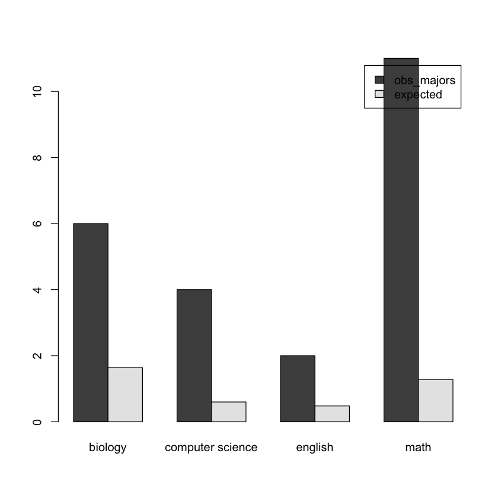

```r
barplot(rbind(obs_majors,expected), beside=TRUE, legend.text=TRUE)
```

# Perform multinomial test using `multinomial.test(obs, null.prop, useChi=True)`

- the obs has to be a vector but we have a table, so use `as.vector(obs)` to convert
- based on thest, do not reject null hypothesis

```r
multinomial.test( as.vector(obs_majors), null.prop, useChisq=TRUE )
```

```
 The model includes 2600 different events.


 Exact Multinomial Test, Chisquare

    Events    chi2Obs    p.value
      2600     3.3448     0.3401
```